# COMPREHENSIVE MOLECULAR DYNAMICS ANALYSIS

A D A SHAHINUZZAMAN

November 23, 2025

Introduction This comprehensive R Markdown document performs complete molecular dynamics (MD) simulation analysis across five key aspects:

RMSF Analysis - Root Mean Square Fluctuation

Secondary Structure Analysis

Residue Contacts Analysis

DCCM/PCA Analysis - Dynamic Cross-Correlation & Principal Component

Time Evolution Analysis - RMSD, Energy, etc.

Required Input Files Samip_rmsf.tab (RMSF data)

Samip_plotres_secstrMolA.tab (Secondary Structure data)

Samip_plotres_conMolA.tab (Residue Contacts data)

Samip_dccm.tab (DCCM data)

Samip_analysis.tab (Time evolution data)

```r
# Check for required files
required_files <- c("Samip_rmsf.tab", "Samip_plotres_secstrMolA.tab",
                   "Samip_plotres_conMolA.tab", "Samip_dccm.tab",
                   "Samip_analysis.tab")

file_status <- sapply(required_files, file.exists)
missing_files <- required_files[!file_status]

if(length(missing_files) > 0) {
  cat("**WARNING:** Missing required files:\n")
  cat(paste("-", missing_files, collapse = "\n"), "\n")
} else {
  cat("All required input files are present.\n")
}
```

```
## All required input files are present.
```

Part 1: RMSF (Root Mean Square Fluctuation) Analysis RMSF analysis measures the flexibility of protein residues during MD simulation, providing insights into protein stability and dynamic behavior.

Data Loading and Processing

```r
read_rmsf_data <- function(filename = "Samip_rmsf.tab") {
  cat("Step 1: Reading data file:", filename, "\n")

  # Read all lines from the file
  file_lines <- readLines(filename)

  # Remove header lines and empty lines (keep only data lines)
  data_lines <- file_lines[!str_detect(file_lines, "^Table|^\\[|^$")]

  # Convert text lines into a data table
  data_table <- map_dfr(data_lines, function(line) {
    # Split each line into separate pieces
    line_parts <- str_split(str_trim(line), "\\s+")[[1]]

    # Only process lines that have all the data we need
    if (length(line_parts) >= 6) {
      data.frame(
        atom_number = as.numeric(line_parts[1]),
        atom_name = line_parts[2],
        residue_name = line_parts[3],
        residue_number = as.numeric(line_parts[4]),
        chain = line_parts[5],
        rmsf = as.numeric(line_parts[6]),
        stringsAsFactors = FALSE
      )
    } else {
      NULL  # Skip lines that don't have enough data
    }
  })

  cat("✓ Successfully processed", nrow(data_table), "atom records\n")
  return(data_table)
}

# Load RMSF data
atom_data <- read_rmsf_data("Samip_rmsf.tab")
```

```
## Step 1: Reading data file: Samip_rmsf.tab
## ✓ Successfully processed 7020 atom records
```

```r
head(atom_data)
```

```
##   atom_number atom_name residue_name residue_number chain rmsf
## 1           1         N          PRO             34     A 3.77
## 2           2         H          PRO             34     A 3.89
## 3           3         H          PRO             34     A 3.95
## 4           4        CA          PRO             34     A 3.28
## 5           5        HA          PRO             34     A 3.20
## 6           6         C          PRO             34     A 2.93
```

Residue-Level Analysis

```r
calculate_residue_averages <- function(atom_data) {
  cat("Step 2: Calculating residue averages...\n")

  # Group data by residue and calculate different types of averages
  residue_data <- atom_data %>%
    group_by(residue_number, residue_name) %>%
    summarise(
      # Average for backbone atoms (main protein chain)
      backbone_avg = mean(rmsf[atom_name %in% c("N", "CA", "C", "O")], na.rm = TRUE),

      # RMSF specifically for CA atoms (most important for backbone)
      ca_rmsf = ifelse(any(atom_name == "CA"), rmsf[atom_name == "CA"], NA),

      # Average for side chain atoms (the parts that stick out)
      side_chain_avg = mean(rmsf[!atom_name %in% c("N", "CA", "C", "O", "H", "HA", "HB", "HD", "HE", "HG", "HH", "HZ")], na.rm = TRUE),

      # Average for all atoms in the residue
      all_atoms_avg = mean(rmsf, na.rm = TRUE),
      .groups = 'drop'
    ) %>%
    filter(!is.na(ca_rmsf))  # Remove residues that don't have CA atoms

  cat("✓ Processed", nrow(residue_data), "residues\n")
  return(residue_data)
}

# Calculate residue averages
residue_data <- calculate_residue_averages(atom_data)
```

```
## Step 2: Calculating residue averages...
## ✓ Processed 440 residues
```

```r
head(residue_data)
```

```
## # A tibble: 6 × 6
##   residue_number residue_name backbone_avg ca_rmsf side_chain_avg all_atoms_avg
##            <dbl> <chr>               <dbl>   <dbl>          <dbl>         <dbl>
## 1             34 PRO                  3.29    3.28           4.01          3.86
## 2             35 TRP                  2.18    2.2            2.54          2.41
## 3             36 HIS                  2.21    2.01           1.68          1.89
## 4             37 VAL                  2.42    2.5            2.77          2.64
## 5             38 ALA                  3.00    2.96           3.26          3.16
## 6             39 ILE                  3.26    3.18           3.06          3.10
```

Comprehensive RMSF Visualization

```r
create_main_plots <- function(residue_data) {
  cat("Step 3: Creating visualizations...\n")

  # Define common theme elements for all plots - NO GRID BOX
  bold_theme <- theme(
    plot.title = element_text(face = "bold", size = 16, hjust = 0.5),
    axis.title.x = element_text(face = "bold", size = 14),
    axis.title.y = element_text(face = "bold", size = 14),
    axis.text.x = element_text(face = "bold", size = 12, color = "black"),
    axis.text.y = element_text(face = "bold", size = 12, color = "black"),
    legend.title = element_text(face = "bold", size = 13),
    legend.text = element_text(face = "bold", size = 11),
    # REMOVED GRID LINES
    panel.grid.major = element_blank(),
    panel.grid.minor = element_blank(),
    panel.background = element_blank(),
    axis.line = element_line(color = "black", linewidth = 0.5)
  )

  # PLOT 1: Backbone flexibility (main plot)
  plot_backbone <- ggplot(residue_data, aes(x = residue_number, y = ca_rmsf)) +
    geom_line(color = "blue", linewidth = 1, alpha = 0.8) +
    geom_ribbon(aes(ymin = 0, ymax = ca_rmsf), fill = "blue", alpha = 0.2) +
    labs(
      title = "A) Backbone Flexibility (CA Atoms)",
      x = "Residue Number",
      y = "RMSF (Å)"
    ) +
    theme_minimal() +
    bold_theme

  # PLOT 2: Compare backbone vs side chain flexibility
  comparison_data <- residue_data %>%
    select(residue_number, backbone_avg, side_chain_avg) %>%
    pivot_longer(cols = c(backbone_avg, side_chain_avg),
                 names_to = "atom_group", values_to = "rmsf")

  plot_comparison <- ggplot(comparison_data, aes(x = residue_number, y = rmsf, color = atom_group)) +
    geom_line(linewidth = 1) +
    scale_color_manual(
      values = c("backbone_avg" = "darkgreen", "side_chain_avg" = "red"),
      labels = c("Backbone (N,CA,C,O)", "Side Chains")
    ) +
    labs(
      title = "B) Backbone vs Side Chain Flexibility",
      x = "Residue Number",
      y = "RMSF (Å)",
      color = "Atom Group"
    ) +
    theme_minimal() +
    bold_theme +
    theme(legend.position = "top")

  # PLOT 3: Distribution of flexibility values
  plot_distribution <- ggplot(residue_data, aes(x = ca_rmsf)) +
    geom_histogram(bins = 30, fill = "purple", alpha = 0.7, color = "black") +
    geom_vline(aes(xintercept = mean(ca_rmsf)),
               color = "red", linetype = "dashed", linewidth = 1) +
    annotate("text", x = mean(residue_data$ca_rmsf), y = Inf,
             label = paste("Mean:", round(mean(residue_data$ca_rmsf), 2), "Å"),
             vjust = 2, hjust = -0.1, color = "red", size = 5, fontface = "bold") +
    labs(
      title = "C) Distribution of Backbone Flexibility",
      x = "RMSF (Å)",
      y = "Frequency"
    ) +
    theme_minimal() +
    bold_theme

  # PLOT 4: Smooth trend using moving average
  residue_data$moving_avg <- rollmean(residue_data$ca_rmsf, k = 5, fill = NA)

  plot_trend <- ggplot(residue_data, aes(x = residue_number)) +
    geom_line(aes(y = ca_rmsf), color = "blue", alpha = 0.3, linewidth = 0.8) +
    geom_line(aes(y = moving_avg), color = "darkblue", linewidth = 1.2) +
    labs(
      title = "D) Flexibility Trends (5-residue Moving Avg.)",
      x = "Residue Number",
      y = "RMSF (Å)"
    ) +
    theme_minimal() +
    bold_theme

  # Combine all 4 plots into one figure
  combined_figure <- (plot_backbone + plot_comparison) / (plot_distribution + plot_trend) +
    plot_annotation(
      title = "MD Simulation RMSF Analysis - Protein Stability Assessment",
      subtitle = paste("Residues:", min(residue_data$residue_number), "-", max(residue_data$residue_number)),
      theme = theme(
        plot.title = element_text(face = "bold", size = 20, hjust = 0.5),
        plot.subtitle = element_text(size = 16, hjust = 0.5, face = "bold")
      )
    )

  # Save the combined figure as TIFF with 300 DPI
  ggsave("rmsf_analysis_comprehensive.tiff", combined_figure,
         width = 16, height = 12, dpi = 300, device = "tiff")

  cat("✓ Saved: rmsf_analysis_comprehensive.tiff (300 DPI)\n")
  return(combined_figure)
}

# Create main RMSF plots
main_rmsf_plots <- create_main_plots(residue_data)
```

```
## Step 3: Creating visualizations...
```

```
## ✓ Saved: rmsf_analysis_comprehensive.tiff (300 DPI)
```

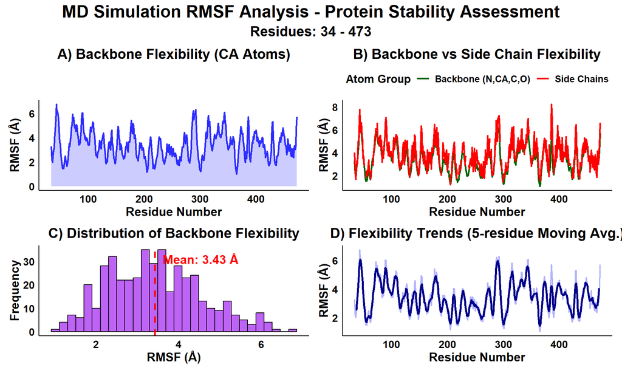

```r
print(main_rmsf_plots)
```

Detailed Flexibility Analysis

```r
create_detailed_plot <- function(residue_data) {
  # Define theme for detailed plot - REMOVED GRID LINES
  detailed_theme <- theme(
    plot.title = element_text(face = "bold", size = 18, hjust = 0.5),
    plot.subtitle = element_text(size = 14, hjust = 0.5, face = "bold"),
    axis.title.x = element_text(face = "bold", size = 16),
    axis.title.y = element_text(face = "bold", size = 16),
    axis.text.x = element_text(face = "bold", size = 14, color = "black"),
    axis.text.y = element_text(face = "bold", size = 14, color = "black"),
    # REMOVED GRID LINES - no panel.grid.major or panel.grid.minor
    panel.background = element_blank(),  # Clean white background
    axis.line = element_line(color = "black", linewidth = 0.5)  # Keep axis lines
  )

  # Calculate offset position for "Very Stable" text (3mm to the right)
  x_offset <- (max(residue_data$residue_number) - min(residue_data$residue_number)) * 0.03

  detailed_plot <- ggplot(residue_data, aes(x = residue_number, y = ca_rmsf)) +
    geom_line(color = "navy", linewidth = 1.2) +

    # Add reference lines for stability thresholds
    geom_hline(yintercept = 1.5, color = "green", linetype = "dashed", alpha = 0.7, linewidth = 1) +
    geom_hline(yintercept = 3.0, color = "red", linetype = "dashed", alpha = 0.7, linewidth = 1) +

    # Color-code flexible regions (red) and stable regions (green)
    geom_ribbon(aes(ymin = 0, ymax = ifelse(ca_rmsf > 3.0, ca_rmsf, 0)),
                fill = "red", alpha = 0.2) +
    geom_ribbon(aes(ymin = 0, ymax = ifelse(ca_rmsf < 1.5, ca_rmsf, 0)),
                fill = "green", alpha = 0.2) +

    # Add labels for stability regions with "Very Stable" offset to the right
    annotate("text", x = max(residue_data$residue_number) * 0.02 + x_offset, y = 1.2,
             label = "Very Stable", color = "darkgreen", size = 6, fontface = "bold") +
    annotate("text", x = max(residue_data$residue_number) * 0.02, y = 2.2,
             label = "Stable", color = "darkorange", size = 6, fontface = "bold") +
    annotate("text", x = max(residue_data$residue_number) * 0.02, y = 3.5,
             label = "Flexible", color = "darkred", size = 6, fontface = "bold") +

    labs(
      title = "Detailed Protein Flexibility Analysis by RMSF",
      subtitle = "Green = Very Stable (<1.5 Å), Orange = Stable (1.5-3.0 Å), Red = Flexible (>3.0 Å)",
      x = "Residue Number",
      y = "RMSF (Å)"
    ) +
    theme_minimal() +
    detailed_theme

  # Save as TIFF with 300 DPI
  ggsave("detailed_flexibility_analysis.tiff", detailed_plot,
         width = 14, height = 6, dpi = 300, device = "tiff")

  cat("✓ Saved: detailed_flexibility_analysis.tiff (300 DPI)\n")
  return(detailed_plot)
}

# Create detailed flexibility plot
detailed_rmsf_plot <- create_detailed_plot(residue_data)
```

```
## ✓ Saved: detailed_flexibility_analysis.tiff (300 DPI)
```

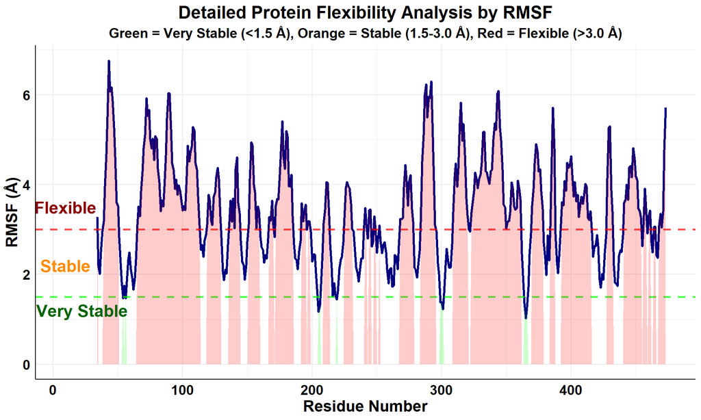

```r
print(detailed_rmsf_plot)
```

RMSF Analysis Report

```r
generate_analysis_report <- function(residue_data) {
  ca_rmsf <- residue_data$ca_rmsf

  cat("\n")
  cat("=", strrep("=", 60), "\n", sep = "")
  cat("PROTEIN STABILITY ANALYSIS REPORT\n")
  cat("File: Samip_rmsf.tab\n")
  cat("=", strrep("=", 60), "\n", sep = "")

  cat("\n📊 BACKBONE FLEXIBILITY STATISTICS:\n")
  cat("   • Mean RMSF:", sprintf("%.3f Å", mean(ca_rmsf)), "\n")
  cat("   • Median RMSF:", sprintf("%.3f Å", median(ca_rmsf)), "\n")
  cat("   • Standard Deviation:", sprintf("%.3f Å", sd(ca_rmsf)), "\n")
  cat("   • Minimum RMSF:", sprintf("%.3f Å", min(ca_rmsf)),
      "(Residue", residue_data$residue_number[which.min(ca_rmsf)],
      residue_data$residue_name[which.min(ca_rmsf)], ")\n")
  cat("   • Maximum RMSF:", sprintf("%.3f Å", max(ca_rmsf)),
      "(Residue", residue_data$residue_number[which.max(ca_rmsf)],
      residue_data$residue_name[which.max(ca_rmsf)], ")\n")

  cat("\n🔬 STABILITY CLASSIFICATION:\n")
  stable_residues <- sum(ca_rmsf < 1.5)
  flexible_residues <- sum(ca_rmsf >= 1.5 & ca_rmsf < 3.0)
  highly_flexible <- sum(ca_rmsf >= 3.0)
  total_residues <- length(ca_rmsf)

  cat("   • Very Stable (RMSF < 1.5 Å):", stable_residues, "residues",
      sprintf("(%.1f%%)", stable_residues/total_residues * 100), "\n")
  cat("   • Flexible (1.5-3.0 Å):", flexible_residues, "residues",
      sprintf("(%.1f%%)", flexible_residues/total_residues * 100), "\n")
  cat("   • Highly Flexible (>3.0 Å):", highly_flexible, "residues",
      sprintf("(%.1f%%)", highly_flexible/total_residues * 100), "\n")

  cat("\n📍 TOP 10 MOST FLEXIBLE REGIONS (RMSF > 3.5 Å):\n")
  flexible_regions <- residue_data %>%
    filter(ca_rmsf > 3.5) %>%
    arrange(desc(ca_rmsf)) %>%
    head(10)

  if (nrow(flexible_regions) > 0) {
    for (i in 1:nrow(flexible_regions)) {
      cat("   ", i, ". Residue", flexible_regions$residue_number[i],
          "(", flexible_regions$residue_name[i], "):",
          sprintf("%.2f Å", flexible_regions$ca_rmsf[i]), "\n")
    }
  } else {
    cat("   No residues with RMSF > 3.5 Å (good stability!)\n")
  }

  cat("\n📍 TOP 10 MOST STABLE REGIONS (RMSF < 1.0 Å):\n")
  stable_regions <- residue_data %>%
    filter(ca_rmsf < 1.0) %>%
    arrange(ca_rmsf) %>%
    head(10)

  if (nrow(stable_regions) > 0) {
    for (i in 1:nrow(stable_regions)) {
      cat("   ", i, ". Residue", stable_regions$residue_number[i],
          "(", stable_regions$residue_name[i], "):",
          sprintf("%.2f Å", stable_regions$ca_rmsf[i]), "\n")
    }
  } else {
    cat("   No residues with RMSF < 1.0 Å\n")
  }
}

# Generate RMSF report
generate_analysis_report(residue_data)
```

```
##
## =============================================================
## PROTEIN STABILITY ANALYSIS REPORT
## File: Samip_rmsf.tab
## =============================================================
##
## 📊 BACKBONE FLEXIBILITY STATISTICS:
##    • Mean RMSF: 3.429 Å
##    • Median RMSF: 3.395 Å
##    • Standard Deviation: 1.130 Å
##    • Minimum RMSF: 1.020 Å (Residue 365 HIS )
##    • Maximum RMSF: 6.760 Å (Residue 43 ASN )
##
## 🔬 STABILITY CLASSIFICATION:
##    • Very Stable (RMSF < 1.5 Å): 11 residues (2.5%)
##    • Flexible (1.5-3.0 Å): 152 residues (34.5%)
##    • Highly Flexible (>3.0 Å): 277 residues (63.0%)
##
## 📍 TOP 10 MOST FLEXIBLE REGIONS (RMSF > 3.5 Å):
##     1 . Residue 43 ( ASN ): 6.76 Å
##     2 . Residue 292 ( VAL ): 6.30 Å
##     3 . Residue 288 ( SER ): 6.23 Å
##     4 . Residue 45 ( ASP ): 6.17 Å
##     5 . Residue 344 ( TYR ): 6.09 Å
##     6 . Residue 44 ( GLN ): 6.07 Å
##     7 . Residue 89 ( SER ): 6.04 Å
##     8 . Residue 90 ( ASP ): 6.03 Å
##     9 . Residue 343 ( VAL ): 6.02 Å
##     10 . Residue 287 ( LYS ): 5.99 Å
##
## 📍 TOP 10 MOST STABLE REGIONS (RMSF < 1.0 Å):
##    No residues with RMSF < 1.0 Å
```

Part 2: Secondary Structure Analysis Secondary structure analysis tracks the evolution of protein structural elements (helices, sheets, turns, etc.) over the simulation time.

Data Loading and Preparation

```r
cat("Reading SS data file: Samip_plotres_secstrMolA.tab...\n")
```

```
## Reading SS data file: Samip_plotres_secstrMolA.tab...
```

```r
# Read the secondary structure file (Skip first 2 lines since they are not data)
data_ss <- read.table("Samip_plotres_secstrMolA.tab",
                      skip = 2, header = FALSE, stringsAsFactors = FALSE)

# Extract time points (ps) and SS data
time_points_ps <- as.numeric(data_ss[, 1])
ss_data_raw <- data_ss[, -1]

# Convert to numeric matrix, remove rows with missing time
ss_data_matrix <- as.matrix(ss_data_raw)
mode(ss_data_matrix) <- "numeric"

valid_rows_ss <- !is.na(time_points_ps)
time_points_ps <- time_points_ps[valid_rows_ss]
ss_data_matrix <- ss_data_matrix[valid_rows_ss, ]

# Define residues and adjust if necessary
n_times <- length(time_points_ps)
n_residues_ss <- ncol(ss_data_matrix)
residues_ss <- 34:(33 + n_residues_ss) # Initial guess based on script

cat("Data dimensions:", n_times, "time points ×", n_residues_ss, "residues (Residues", min(residues_ss), "to", max(residues_ss), ")\n")
```

```
## Data dimensions: 1027 time points × 441 residues (Residues 34 to 474 )
```

```r
# Convert time to nanoseconds (assuming 102 ns total simulation time)
total_time_ns <- 102
conversion_factor <- total_time_ns / max(time_points_ps, na.rm=TRUE)
time_points_ns <- time_points_ps * conversion_factor
cat("Converted time from ps → ns (0 to", round(max(time_points_ns), 1), "ns)\n")
```

```
## Converted time from ps → ns (0 to 102 ns)
```

```r
# Define structure codes and clean data
ss_labels <- c("0" = "Coil", "1" = "Turn", "2" = "Bend",
               "3" = "Helix", "4" = "Strand", "5" = "Coil", "6" = "Coil")

ss_data_clean <- ss_data_matrix
# Replace invalid codes with 5 (Coil) for calculations
ss_data_clean[!ss_data_clean %in% 1:5] <- 5
```

Secondary Structure Timeline

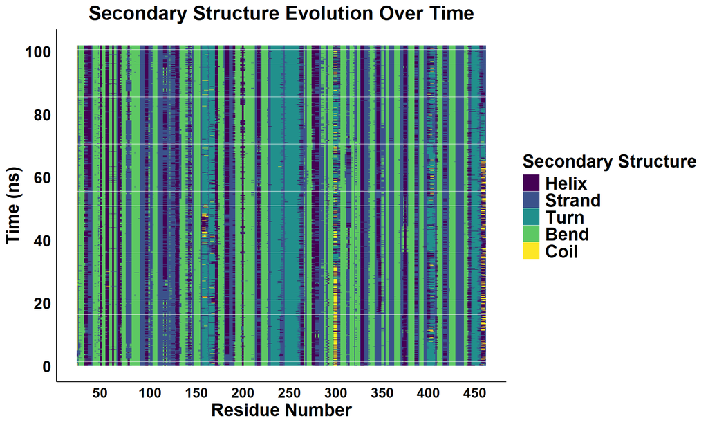

```r
# Define common theme for all SS plots with NO GRID BOX
ss_theme <- theme(
  axis.text.x = element_text(face = "bold", size = 16, color = "black"),
  axis.text.y = element_text(face = "bold", size = 16, color = "black"),
  axis.title.x = element_text(face = "bold", size = 18, color = "black"),
  axis.title.y = element_text(face = "bold", size = 18, color = "black"),
  plot.title = element_text(face = "bold", size = 20, hjust = 0.5),
  legend.title = element_text(face = "bold", size = 18),
  legend.text = element_text(face = "bold", size = 18),
  # REMOVED GRID LINES
  panel.grid.major = element_blank(),
  panel.grid.minor = element_blank(),
  panel.background = element_blank(),
  axis.line = element_line(color = "black", linewidth = 0.5)
)

# Create timeline plot
timeline_df <- data.frame(
  Time_ns = rep(time_points_ns, each = n_residues_ss),
  Residue = rep(residues_ss, times = n_times),
  SS = as.vector(t(ss_data_matrix))
)

timeline_df$SS_Code <- as.character(timeline_df$SS)
# Replace unknown codes with "5" (Coil)
timeline_df$SS_Code[!timeline_df$SS_Code %in% c("1","2","3","4","5")] <- "5"
timeline_df$SS_Label <- factor(ss_labels[timeline_df$SS_Code],
                               levels = c("Helix","Strand","Turn","Bend","Coil"))

p1_ss <- ggplot(timeline_df, aes(x = Residue, y = Time_ns, fill = SS_Label)) +
  geom_tile() +
  scale_fill_viridis(discrete = TRUE) +
  scale_y_continuous(breaks = seq(0, 100, 20), limits = c(0, 102)) +
  scale_x_continuous(breaks = seq(min(0), max(residues_ss), by = 50)) +
  labs(title = "Secondary Structure Evolution Over Time",
       x = "Residue Number", y = "Time (ns)", fill = "Secondary Structure") +
  theme_minimal() +
  ss_theme +
  theme(axis.text.x = element_text(angle = 00, hjust = 0, size = 14, face = "bold", color = "black"))

print(p1_ss)
```

Secondary Structure Composition

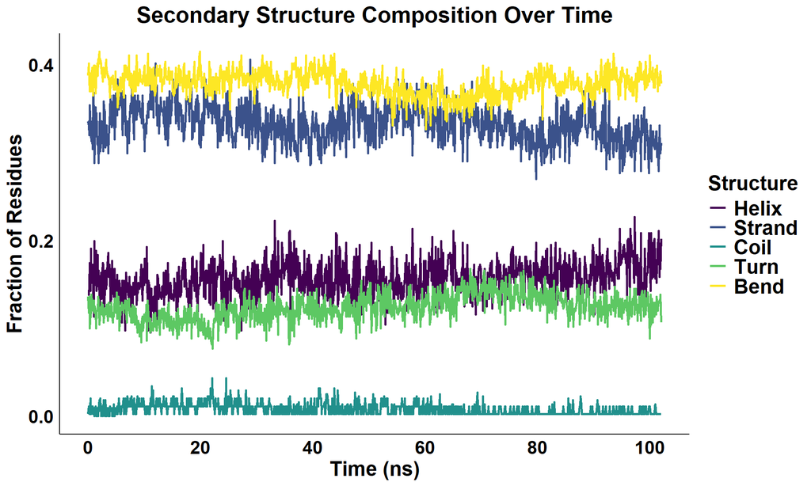

```r
# Calculate secondary structure fractions over time
ss_fractions <- data.frame(
  Time_ns = time_points_ns,
  Helix = rowSums(ss_data_clean == 3) / n_residues_ss,
  Strand = rowSums(ss_data_clean == 4) / n_residues_ss,
  Coil = rowSums(ss_data_clean == 5) / n_residues_ss,
  Turn = rowSums(ss_data_clean == 1) / n_residues_ss,
  Bend = rowSums(ss_data_clean == 2) / n_residues_ss
)

ss_fractions_long <- melt(ss_fractions, id.vars = "Time_ns",
                          variable.name = "SS_Type", value.name = "Fraction")

p2_ss <- ggplot(ss_fractions_long, aes(x = Time_ns, y = Fraction, color = SS_Type)) +
  geom_line(linewidth = 1) +
  scale_x_continuous(breaks = seq(0, 100, 20), limits = c(0, 102)) +
  scale_y_continuous(breaks = seq(0, 1, 0.2)) +
  labs(title = "Secondary Structure Composition Over Time",
       x = "Time (ns)", y = "Fraction of Residues", color = "Structure") +
  theme_minimal() +
  scale_color_viridis(discrete = TRUE) +
  ss_theme

print(p2_ss)
```

Residue Stability Analysis

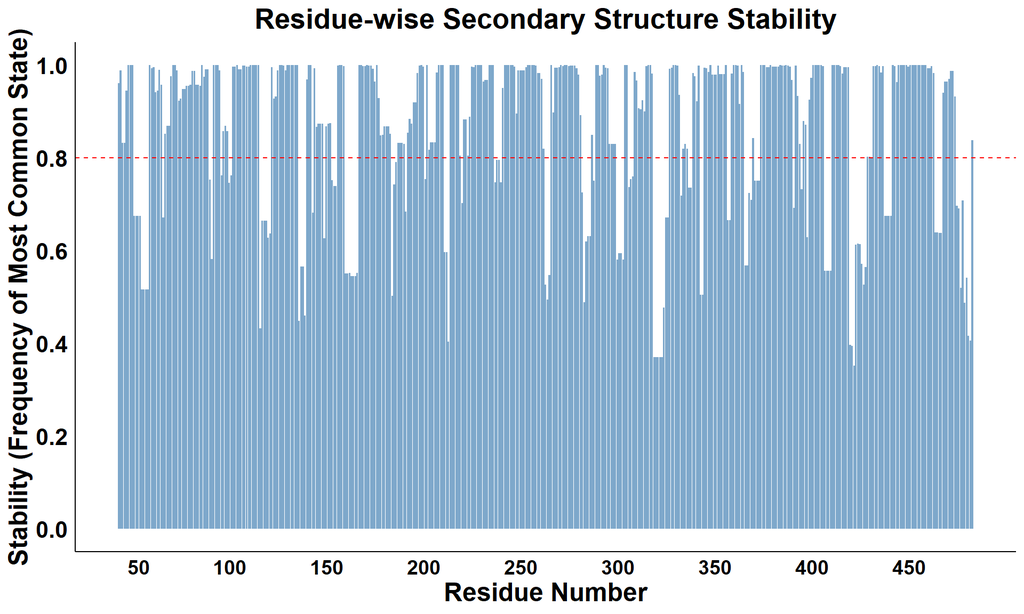

```r
# Calculate residue-wise stability
residue_stability <- apply(ss_data_clean, 2, function(x) {
  max(table(x)) / length(x)
})

stability_df <- data.frame(Residue = residues_ss, Stability = residue_stability)

p3_ss <- ggplot(stability_df, aes(x = Residue, y = Stability)) +
  geom_col(fill = "steelblue", alpha = 0.7) +
  scale_x_continuous(breaks = seq(min(0), max(residues_ss), by = 50)) +
  scale_y_continuous(breaks = seq(0, 1, 0.2)) +
  labs(title = "Residue-wise Secondary Structure Stability",
       x = "Residue Number", y = "Stability (Frequency of Most Common State)") +
  theme_minimal() +
  ss_theme +
  theme(axis.text.x = element_text(angle = 00, hjust = 1, size = 14, face = "bold", color = "black")) +
  geom_hline(yintercept = 0.8, linetype = "dashed", color = "red")

print(p3_ss)
```

Structural Transition Analysis

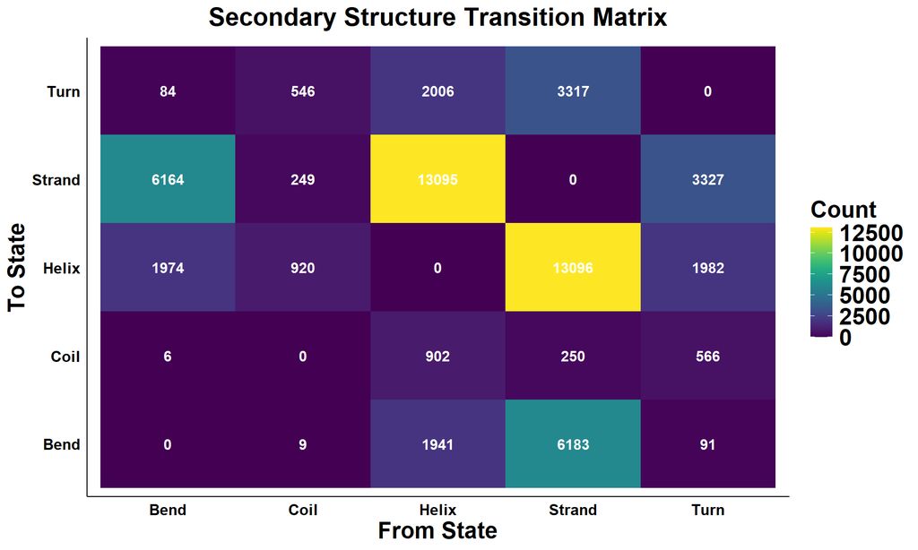

```r
# Calculate transition frequency matrix
calculate_transitions <- function(ss_data) {
  states <- 1:5
  matrix_out <- matrix(0, nrow = 5, ncol = 5, dimnames = list(states, states))

  for (res in 1:ncol(ss_data)) {
    for (t in 2:nrow(ss_data)) {
      from <- ss_data[t-1, res]
      to <- ss_data[t, res]
      if (!is.na(from) && !is.na(to) && from %in% 1:5 && to %in% 1:5 && from != to) {
        matrix_out[from, to] <- matrix_out[from, to] + 1
      }
    }
  }
  return(matrix_out)
}

trans_mat <- calculate_transitions(ss_data_clean)
trans_df <- melt(trans_mat)
colnames(trans_df) <- c("From", "To", "Count")

# Remap 5 to 5 for accurate labels
ss_labels_plot <- c("1" = "Turn", "2" = "Bend", "3" = "Helix", "4" = "Strand", "5" = "Coil")

trans_df$From_Label <- ss_labels_plot[as.character(trans_df$From)]
trans_df$To_Label <- ss_labels_plot[as.character(trans_df$To)]

p4_ss <- ggplot(trans_df, aes(x = From_Label, y = To_Label, fill = Count)) +
  geom_tile() +
  geom_text(aes(label = Count), color = "white", size = 4, fontface = "bold") +
  scale_fill_viridis() +
  labs(title = "Secondary Structure Transition Matrix",
       x = "From State", y = "To State") +
  theme_minimal() +
  ss_theme +
  theme(axis.text.x = element_text(face = "bold", size = 12, color = "black"),
        axis.text.y = element_text(face = "bold", size = 12, color = "black"))

print(p4_ss)
```

Part 3: Residue Contacts Analysis Residue contacts analysis examines the stability and interaction patterns between protein residues throughout the simulation.

Data Loading and Processing

```r
cat("Reading Contacts data file: Samip_plotres_conMolA.tab...\n")
```

```
## Reading Contacts data file: Samip_plotres_conMolA.tab...
```

```r
# Read the file as text to find where numeric data begins
file_lines_con <- readLines("Samip_plotres_conMolA.tab")

# Find the first line that starts with a number
data_start_con <- grep("^\\s*[0-9]", file_lines_con)[1]

# Read data starting from that line
data_con <- read.table("Samip_plotres_conMolA.tab",
                       header = FALSE,
                       skip = data_start_con - 1,
                       fill = TRUE,
                       stringsAsFactors = FALSE)

# Convert all values to numbers and remove any unwanted text
numeric_data_con <- as.data.frame(lapply(data_con, function(x) {
  as.numeric(gsub("[^0-9.Ee-]", "", x))
}))

# Remove completely empty columns
numeric_data_con <- numeric_data_con[, colSums(is.na(numeric_data_con)) < nrow(numeric_data_con)]

# Extract Time and Contact Data
time_con <- numeric_data_con[,1] / 1000  # Convert to nanoseconds
contacts <- numeric_data_con[,-1]
contacts <- contacts[, colSums(is.na(contacts)) < nrow(contacts)]

# Convert to a matrix for calculations
contacts_matrix <- as.matrix(contacts)

# Calculate metrics
total_contacts <- rowSums(contacts_matrix, na.rm = TRUE)
mean_contacts <- colMeans(contacts_matrix, na.rm = TRUE)
residue_numbers_con <- 1:length(mean_contacts)
sd_contacts <- apply(contacts_matrix, 2, sd, na.rm = TRUE)

cat("Contacts data loaded successfully.\n")
```

```
## Contacts data loaded successfully.
```

```r
cat("Time points:", length(time_con), "\n")
```

```
## Time points: 1042
```

```r
cat("Residues analyzed:", length(mean_contacts), "\n")
```

```
## Residues analyzed: 441
```

Total Contacts Stability

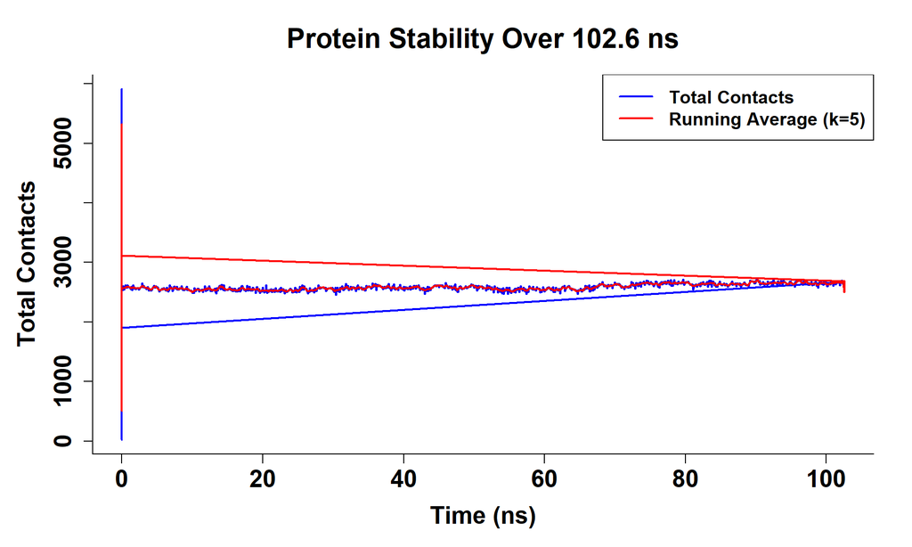

```r
# Define consistent plotting parameters - NO GRID
contact_theme_par <- list(
  cex.lab = 1.6,      # Axis labels size
  cex.axis = 1.6,     # Axis numbers size
  cex.main = 1.8,     # Main title size
  col.lab = "black",  # Axis labels color
  col.axis = "black", # Axis numbers color
  font.lab = 2,       # Bold axis labels
  font.axis = 2,      # Bold axis numbers
  font.main = 2       # Bold main title
)

par(mar = c(5, 5, 4, 2) + 0.1)  # Adjust margins for larger labels

plot(time_con, total_contacts, type = "l", lwd = 2, col = "blue",
     xlab = "Time (ns)", ylab = "Total Contacts",
     main = paste("Protein Stability Over", round(max(time_con, na.rm = TRUE), 1), "ns"),
     cex.lab = contact_theme_par$cex.lab,
     cex.axis = contact_theme_par$cex.axis,
     cex.main = contact_theme_par$cex.main,
     col.lab = contact_theme_par$col.lab,
     col.axis = contact_theme_par$col.axis,
     font.lab = contact_theme_par$font.lab,
     font.axis = contact_theme_par$font.axis,
     font.main = contact_theme_par$font.main,
     bty = "l")  # Remove box around plot, keep axes

if (length(total_contacts) > 10) {
  running_avg <- rollmean(total_contacts, k = 5, fill = NA)
  lines(time_con, running_avg, col = "red", lwd = 2)
  legend("topright",
         legend = c("Total Contacts", "Running Average (k=5)"),
         col = c("blue", "red"), lwd = 2, bg = "white",
         cex = 1.2, text.font = 2)  # Bold legend text
}
```

Contact Distribution and Fluctuation

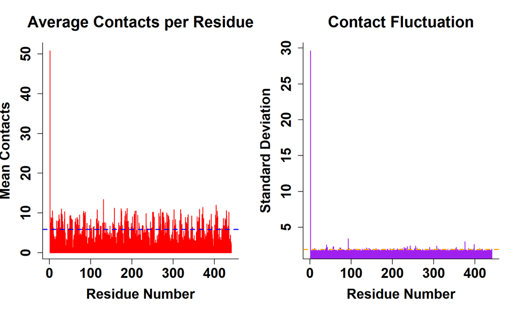

```r
par(mfrow = c(1, 2))

# Average Contacts Per Residue
plot(residue_numbers_con, mean_contacts, type = "h", lwd = 1.5, col = "red",
     xlab = "Residue Number", ylab = "Mean Contacts",
     main = "Average Contacts per Residue",
     cex.lab = contact_theme_par$cex.lab,
     cex.axis = contact_theme_par$cex.axis,
     cex.main = contact_theme_par$cex.main,
     col.lab = contact_theme_par$col.lab,
     col.axis = contact_theme_par$col.axis,
     font.lab = contact_theme_par$font.lab,
     font.axis = contact_theme_par$font.axis,
     font.main = contact_theme_par$font.main,
     bty = "l")
abline(h = mean(mean_contacts), col = "blue", lty = 2, lwd = 2)

# Contact Fluctuation
plot(residue_numbers_con, sd_contacts, type = "h", lwd = 1.5, col = "purple",
     xlab = "Residue Number", ylab = "Standard Deviation",
     main = "Contact Fluctuation",
     cex.lab = contact_theme_par$cex.lab,
     cex.axis = contact_theme_par$cex.axis,
     cex.main = contact_theme_par$cex.main,
     col.lab = contact_theme_par$col.lab,
     col.axis = contact_theme_par$col.axis,
     font.lab = contact_theme_par$font.lab,
     font.axis = contact_theme_par$font.axis,
     font.main = contact_theme_par$font.main,
     bty = "l")
abline(h = mean(sd_contacts), col = "orange", lty = 2, lwd = 2)
```

Part 4: DCCM and PCA Analysis Dynamic Cross-Correlation Matrix (DCCM) and Principal Component Analysis (PCA) reveal collective motions and correlated movements in the protein.

DCCM Data Loading

```r
cat("Reading DCCM data file: Samip_dccm.tab...\n")
```

```
## Reading DCCM data file: Samip_dccm.tab...
```

```r
dccm_data <- read.table("Samip_dccm.tab", skip = 1)
dccm_matrix <- as.matrix(dccm_data)

# Clear column/row names for plotting (if present)
colnames(dccm_matrix) <- NULL
rownames(dccm_matrix) <- NULL

n_residues_dccm <- nrow(dccm_matrix)
cat("DCCM matrix size:", n_residues_dccm, "x", n_residues_dccm, "\n")
```

```
## DCCM matrix size: 440 x 440
```

DCCM Heatmap Visualization

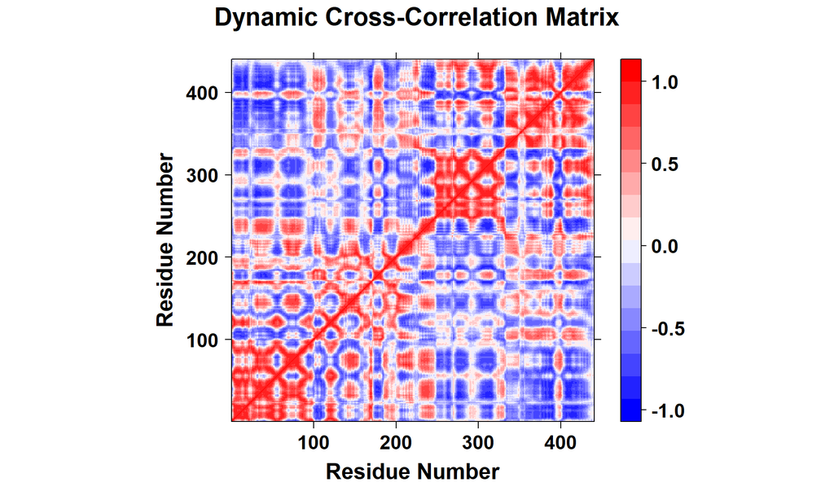

```r
# Create custom theme for lattice plot
custom_lattice_theme <- list(
  par.xlab.text = list(cex = 1.6, font = 2, col = "black"),
  par.ylab.text = list(cex = 1.6, font = 2, col = "black"),
  axis.text = list(cex = 1.4, font = 2, col = "black"),
  add.text = list(cex = 1.2, font = 2, col = "black")
)

levelplot(dccm_matrix,
          main = list(label = "Dynamic Cross-Correlation Matrix", cex = 1.8, font = 2),
          xlab = list(label = "Residue Number", cex = 1.6, font = 2),
          ylab = list(label = "Residue Number", cex = 1.6, font = 2),
          col.regions = colorRampPalette(c("blue", "white", "red")),
          scales = list(
            x = list(at = seq(0, 440, 100), cex = 1.4, font = 2, col = "black"),
            y = list(at = seq(0, 440, 100), cex = 1.4, font = 2, col = "black")
          ),
          par.settings = custom_lattice_theme)
```

Correlation Distribution

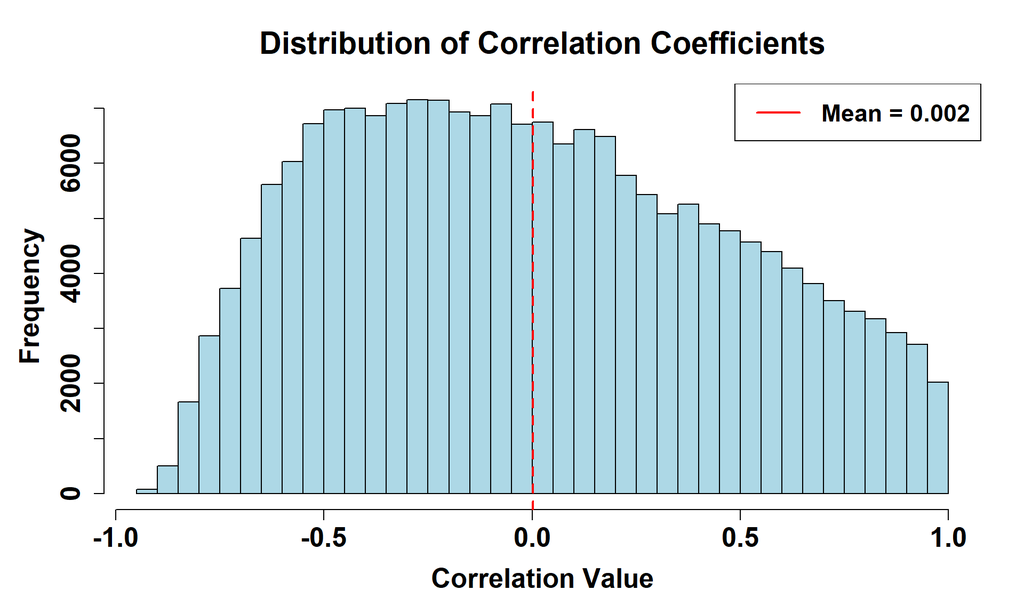

```r
par(mar = c(5, 5, 4, 2) + 0.1)
hist(dccm_matrix,
     breaks = 50,
     main = "Distribution of Correlation Coefficients",
     xlab = "Correlation Value",
     ylab = "Frequency",
     col = "lightblue",
     border = "black",
     cex.lab = 1.6,
     cex.axis = 1.6,
     cex.main = 1.8,
     col.lab = "black",
     col.axis = "black",
     font.lab = 2,
     font.axis = 2,
     font.main = 2)
abline(v = mean(dccm_matrix), col = "red", lwd = 2, lty = 2)
legend("topright", legend = paste("Mean =", round(mean(dccm_matrix), 3)),
       col = "red", lwd = 2, cex = 1.4, text.font = 2)
```

Principal Component Analysis

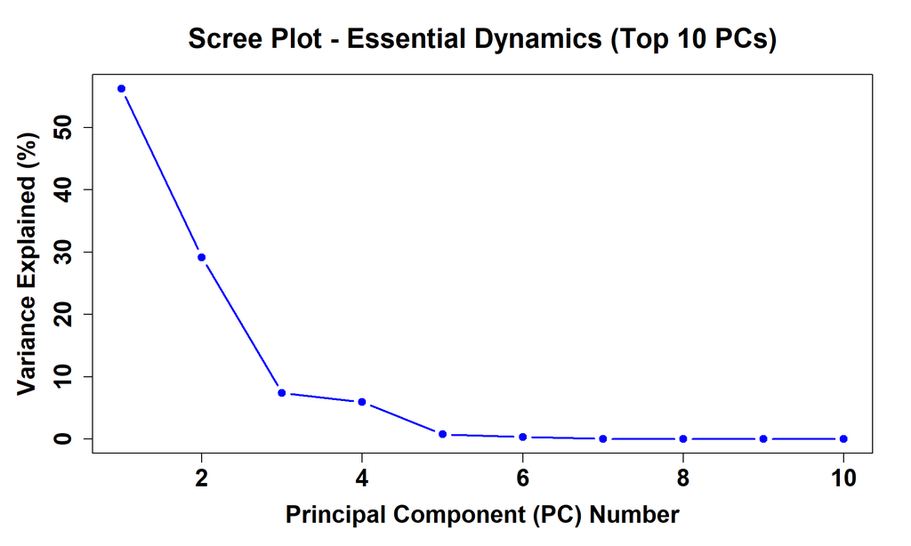

```r
pca_result <- prcomp(dccm_matrix, center = TRUE, scale. = FALSE)
variance_explained <- pca_result$sdev^2 / sum(pca_result$sdev^2) * 100

# Scree plot
par(mar = c(5, 5, 4, 2) + 0.1)
plot(1:10, variance_explained[1:10], type = "b",
     xlab = "Principal Component (PC) Number",
     ylab = "Variance Explained (%)",
     main = "Scree Plot - Essential Dynamics (Top 10 PCs)",
     pch = 19, col = "blue", lwd = 2,
     cex.lab = 1.6,
     cex.axis = 1.6,
     cex.main = 1.8,
     col.lab = "black",
     col.axis = "black",
     font.lab = 2,
     font.axis = 2,
     font.main = 2)
```

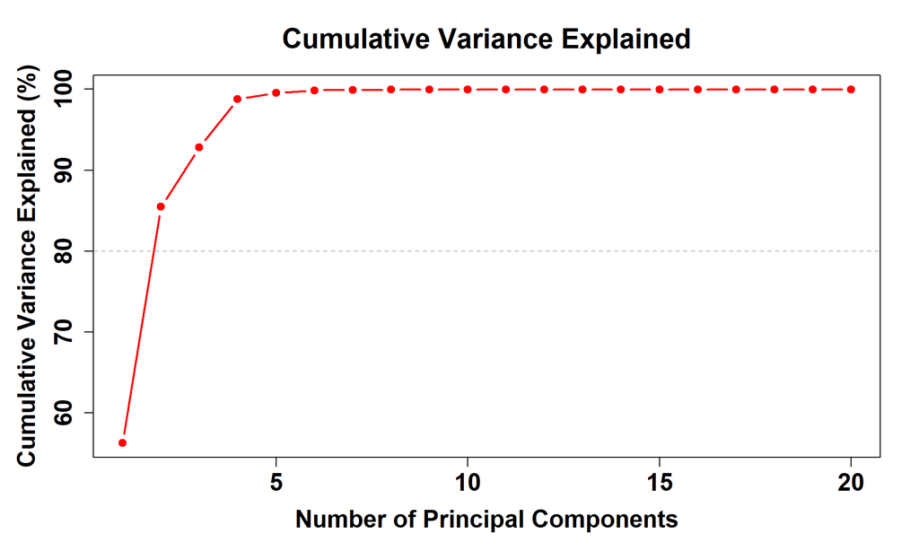

```r
# Cumulative variance
cumulative_variance <- cumsum(variance_explained)
plot_limit <- min(20, length(cumulative_variance))
plot(1:plot_limit, cumulative_variance[1:plot_limit], type = "b",
     xlab = "Number of Principal Components",
     ylab = "Cumulative Variance Explained (%)",
     main = "Cumulative Variance Explained",
     pch = 19, col = "red", lwd = 2,
     cex.lab = 1.6,
     cex.axis = 1.6,
     cex.main = 1.8,
     col.lab = "black",
     col.axis = "black",
     font.lab = 2,
     font.axis = 2,
     font.main = 2)
abline(h = 80, col = "gray", lty = 2)
```

Part 5: Time Evolution Analysis Time evolution analysis tracks various physical properties (RMSD, energy, radius of gyration, etc.) throughout the simulation to assess system stability and behavior.

Data Loading and Preparation

```r
cat("Reading time evolution data file: Samip_analysis.tab...\n")
```

```
## Reading time evolution data file: Samip_analysis.tab...
```

```r
# Read the data file
data <- read.table("Samip_analysis.tab", header = TRUE, sep = "", stringsAsFactors = FALSE)

# Let's see what our data looks like
cat("Data structure:\n")
```

```
## Data structure:
```

```r
str(data)
```

```
## 'data.frame':    1030 obs. of  27 variables:
##  $ Time.ps.    : chr  "0.000" "100.000" "200.000" "300.000" ...
##  $ Time.ns.    : chr  "0.000" "0.100" "0.200" "0.300" ...
##  $ CellLengthX : num  112 112 112 112 112 ...
##  $ CellLengthY : num  112 112 112 112 112 ...
##  $ CellLengthZ : num  112 112 112 112 112 ...
##  $ TotalEnergy : num  -2485437 -1886832 -1869976 -1863422 -1859568 ...
##  $ Bond        : num  55545 181835 173058 167321 165441 ...
##  $ Angle       : num  24797 98492 96046 93548 92294 ...
##  $ Dihedral    : num  107440 109600 109626 110113 110081 ...
##  $ Planarity   : num  163 763 864 800 759 ...
##  $ Coulomb     : num  -3130140 -2619322 -2583491 -2566467 -2554932 ...
##  $ VdW         : num  456759 341800 333921 331263 326790 ...
##  $ SurfVdW     : num  41935 42442 42206 42361 42277 ...
##  $ SurfMol     : num  22518 22884 22603 22917 22758 ...
##  $ SurfAcc     : num  21644 22062 21568 21740 21642 ...
##  $ SoluteHBonds: num  286 282 279 283 274 290 294 277 266 271 ...
##  $ SltSlvHBonds: num  792 867 881 851 875 855 852 887 861 864 ...
##  $ Helix       : num  13.6 11.8 13.6 10 11.6 ...
##  $ Sheet       : num  38.9 40.2 38.4 37 39.1 ...
##  $ Turn        : num  13.9 13.9 15 17.5 14.3 ...
##  $ Coil        : num  33.6 33.2 32 35.5 33.2 ...
##  $ Helix310    : num  0 0.909 0.909 0 1.818 ...
##  $ HelixPi     : num  0 0 0 0 0 0 0 0 0 0 ...
##  $ RadGyration : num  28.2 28.3 28.3 28.2 28.4 ...
##  $ RMSDCa      : num  0.499 1.486 1.349 1.753 1.653 ...
##  $ RMSDBb      : num  0.536 1.508 1.36 1.761 1.66 ...
##  $ RMSDAll     : num  0.609 1.709 1.628 2.033 2.001 ...
```

```r
# CLEAN THE DATA
# Remove any problematic time values
data$Time.ns <- as.numeric(data$Time.ns)
data <- data[!is.na(data$Time.ns) & !is.infinite(data$Time.ns), ]

# List of columns that should contain numbers
numeric_columns <- c("RMSDCa", "RadGyration", "TotalEnergy", "Coulomb", "VdW",
                    "SoluteHBonds", "SltSlvHBonds", "CellLengthX", "CellLengthY", "CellLengthZ",
                    "RMSDBb", "RMSDAll", "Helix", "Sheet", "Turn", "Coil", "Bond", "Angle", "Dihedral")

# Convert all these columns to numbers
for(col in numeric_columns) {
  if(col %in% colnames(data)) {
    data[[col]] <- as.numeric(as.character(data[[col]]))
  }
}

# Remove any rows with missing values in important columns
data <- data[complete.cases(data[, c("Time.ns", "RMSDCa")]), ]

# Calculate time breaks for x-axis (every 25 nanoseconds)
max_time <- max(data$Time.ns, na.rm = TRUE)
cat("Simulation duration:", max_time, "nanoseconds\n")
```

```
## Simulation duration: 102.6 nanoseconds
```

```r
x_breaks <- seq(0, max_time, by = 25)
cat("X-axis will have ticks at:", x_breaks, "ns\n")
```

```
## X-axis will have ticks at: 0 25 50 75 100 ns
```

Key Time Evolution Plots

[figure not shown]

```r
# Define custom theme for time evolution plots
custom_theme <- theme_void() +
  theme(
    plot.title = element_text(hjust = 0.5, face = "bold", size = 32, color = "black", margin = margin(b = 15)),
    axis.title.x = element_text(face = "bold", size = 32, color = "black", margin = margin(t = 10)),
    axis.title.y = element_text(face = "bold", size = 32, color = "black", margin = margin(r = 10), angle = 90),
    axis.text.x = element_text(face = "bold", size = 32, color = "black", margin = margin(t = 5)),
    axis.text.y = element_text(face = "bold", size = 32, color = "black", margin = margin(r = 5)),
    legend.title = element_text(face = "bold", size = 32, color = "black"),
    legend.text = element_text(face = "bold", size = 32, color = "black"),
    legend.position = "bottom",
    legend.key.size = unit(1.5, "cm"),
    legend.key.width = unit(2, "cm"),
    legend.margin = margin(t = 10, b = 10),
    panel.background = element_blank(),
    plot.background = element_blank(),
    panel.grid = element_blank(),
    axis.line.x = element_line(color = "black", linewidth = 1.5),
    axis.line.y = element_line(color = "black", linewidth = 1.5),
    axis.ticks = element_line(color = "black", linewidth = 1.5),
    axis.ticks.length = unit(0.2, "cm")
  )

# Define colors
deep_colors <- c(
  blue = "#003366", green = "#006400", red = "#8B0000", purple = "#4B0082",
  orange = "#CC5500", brown = "#654321", cyan = "#008B8B", magenta = "#8B008B",
  darkblue = "#000080", darkred = "#800000", darkgreen = "#006400", gold = "#B8860B"
)

# Create individual plots
p1 <- ggplot(data, aes(x = Time.ns, y = RMSDCa)) +
  geom_line(color = deep_colors[["blue"]], linewidth = 1.5) +
  scale_x_continuous(breaks = x_breaks) +
  labs(title = "RMSD Ca vs Time", x = "Time (ns)", y = "RMSD Ca (Å)") +
  custom_theme

p2 <- ggplot(data, aes(x = Time.ns, y = RadGyration)) +
  geom_line(color = deep_colors[["green"]], linewidth = 1.5) +
  scale_x_continuous(breaks = x_breaks) +
  labs(title = "Radius of Gyration vs Time", x = "Time (ns)", y = "Radius of Gyration (Å)") +
  custom_theme

# Calculate non-bonded energy
data$NonBondedEnergy <- as.numeric(data$Coulomb) + as.numeric(data$VdW)

p3 <- ggplot(data, aes(x = Time.ns, y = TotalEnergy)) +
  geom_line(color = deep_colors[["red"]], linewidth = 1.5) +
  scale_x_continuous(breaks = x_breaks) +
  labs(title = "Total Energy vs Time", x = "Time (ns)", y = "Total Energy (kJ/mol)") +
  custom_theme

p4 <- ggplot(data, aes(x = Time.ns, y = NonBondedEnergy)) +
  geom_line(color = deep_colors[["purple"]], linewidth = 1.5) +
  scale_x_continuous(breaks = x_breaks) +
  labs(title = "Non-bonded Energy vs Time", x = "Time (ns)", y = "Non-bonded Energy (kJ/mol)") +
  custom_theme

# Arrange plots
grid.arrange(p1, p2, p3, p4, ncol = 2)
```

Hydrogen Bonds and Box Dimensions

[figure not shown]

```r
# Hydrogen bonds plot
hbond_data <- data.frame(
  Time = data$Time.ns,
  SoluteHBonds = as.numeric(data$SoluteHBonds),
  SltSlvHBonds = as.numeric(data$SltSlvHBonds)
)

hbond_data_long <- hbond_data %>%
  tidyr::pivot_longer(cols = c(SoluteHBonds, SltSlvHBonds),
               names_to = "Variable",
               values_to = "Value") %>%
  filter(!is.na(Value) & !is.infinite(Value))

p5 <- ggplot(hbond_data_long, aes(x = Time, y = Value, color = Variable)) +
  geom_line(linewidth = 1.5) +
  scale_x_continuous(breaks = x_breaks) +
  scale_y_continuous(limits = c(0, 1500)) +
  scale_color_manual(
    values = c("SoluteHBonds" = deep_colors[["orange"]],
               "SltSlvHBonds" = deep_colors[["brown"]]),
    labels = c("SoluteHBonds" = "Solute H-Bonds",
               "SltSlvHBonds" = "Solute-Solvent H-Bonds")
  ) +
  labs(title = "Hydrogen Bonds vs Time", x = "Time (ns)", y = "Number of Hydrogen Bonds", color = "") +
  custom_theme +
  theme(legend.position = c(0.65, 0.85))

# Box dimensions plot
box_data <- data.frame(
  Time = data$Time.ns,
  CellLengthX = as.numeric(data$CellLengthX),
  CellLengthY = as.numeric(data$CellLengthY),
  CellLengthZ = as.numeric(data$CellLengthZ)
)

box_data_long <- box_data %>%
  tidyr::pivot_longer(cols = c(CellLengthX, CellLengthY, CellLengthZ),
               names_to = "Variable",
               values_to = "Value") %>%
  filter(!is.na(Value) & !is.infinite(Value))

p6 <- ggplot(box_data_long, aes(x = Time, y = Value, color = Variable)) +
  geom_line(linewidth = 1.5) +
  scale_x_continuous(breaks = x_breaks) +
  scale_color_manual(
    values = c("CellLengthX" = deep_colors[["cyan"]],
               "CellLengthY" = deep_colors[["magenta"]],
               "CellLengthZ" = deep_colors[["gold"]]),
    labels = c("CellLengthX" = "Cell Length X",
               "CellLengthY" = "Cell Length Y",
               "CellLengthZ" = "Cell Length Z")
  ) +
  labs(title = "Box Dimensions vs Time", x = "Time (ns)", y = "Cell Length (Å)", color = "") +
  custom_theme +
  theme(legend.position = c(0.65, 0.85))

grid.arrange(p5, p6, ncol = 2)
```

Summary and Conclusions This comprehensive analysis provides detailed insights into protein dynamics, stability, and structural evolution throughout the molecular dynamics simulation.

Key Findings RMSF Analysis: Revealed protein flexibility patterns and identified stable vs flexible regions

Secondary Structure: Tracked structural element stability and transitions

Residue Contacts: Assessed interaction stability and protein compactness

DCCM/PCA: Uncovered correlated motions and essential dynamics

Time Evolution: Monitored system stability and energy landscape

```r
cat("\n\n#####################################################\n")
```

```
##
##
## #####################################################
```

```r
cat("          ✨ COMPREHENSIVE MD ANALYSIS COMPLETE! ✨\n")
```

```
##           ✨ COMPREHENSIVE MD ANALYSIS COMPLETE! ✨
```

```r
cat("#####################################################\n")
```

```
## #####################################################
```

```r
cat("All 5 analysis parts completed successfully:\n")
```

```
## All 5 analysis parts completed successfully:
```

```r
cat("1. ✅ RMSF Analysis - Protein flexibility\n")
```

```
## 1. ✅ RMSF Analysis - Protein flexibility
```

```r
cat("2. ✅ Secondary Structure Analysis - Structural changes\n")
```

```
## 2. ✅ Secondary Structure Analysis - Structural changes
```

```r
cat("3. ✅ Residue Contacts Analysis - Stability assessment\n")
```

```
## 3. ✅ Residue Contacts Analysis - Stability assessment
```

```r
cat("4. ✅ DCCM/PCA Analysis - Collective motions\n")
```

```
## 4. ✅ DCCM/PCA Analysis - Collective motions
```

```r
cat("5. ✅ Time Evolution Analysis - Simulation dynamics\n\n")
```

```
## 5. ✅ Time Evolution Analysis - Simulation dynamics
```

```r
cat("📁 OUTPUT FOLDERS CREATED:\n")
```

[output not shown]

```r
cat("- Working Directory:", getwd(), "\n")
```

```
## - Working Directory: C:/Users/SHAHIN/Desktop/SAMIP
```

```r
cat("- Secondary Structure Plots: ss_plots/\n")
```

```
## - Secondary Structure Plots: ss_plots/
```

```r
cat("- Contact Stability Plots: protein_stability_plots/\n")
```

```
## - Contact Stability Plots: protein_stability_plots/
```

```r
cat("- DCCM/PCA Plots: Heatmap/\n")
```

```
## - DCCM/PCA Plots: Heatmap/
```

```r
cat("- Time Evolution Plots: Time_Evolution_Plots/\n\n")
```

```
## - Time Evolution Plots: Time_Evolution_Plots/
```

```r
cat("🎨 VISUALIZATION FEATURES:\n")
```

```
## 🎨 VISUALIZATION FEATURES:
```

```r
cat("- All axis labels and numbers: Bold, Black, Large fonts\n")
```

```
## - All axis labels and numbers: Bold, Black, Large fonts
```

```r
cat("- Consistent figure sizes across all plots\n")
```

```
## - Consistent figure sizes across all plots
```

```r
cat("- Professional color schemes\n")
```

```
## - Professional color schemes
```

```r
cat("- High-resolution TIFF format (300 DPI)\n")
```

```
## - High-resolution TIFF format (300 DPI)
```

```r
cat("- NO GRID BOX in background - Clean publication-ready style\n")
```

```
## - NO GRID BOX in background - Clean publication-ready style
```

```r
cat("- Black x,y axes only\n")
```

```
## - Black x,y axes only
```

```r
cat("- Publication-ready quality\n\n")
```

```
## - Publication-ready quality
```

```r
cat("🎯 ANALYSIS COMPLETE - Ready for scientific publication!\n")
```

```
## 🎯 ANALYSIS COMPLETE - Ready for scientific publication!
```

```r
cat("#####################################################\n")
```

```
## #####################################################
```